# Risk Factor Analysis

## Outcome Variable

**Outcome Variable:** wasted

## Predictor Variables

**Intervention Variable:** feducyrs

**Adjustment Set:**

- arm
- W_mage
- meducyrs
- hhwealth_quart
- W_mhtcm
- W_mwtkg
- W_mbmi
- W_gagebrth
- W_birthwt
- W_birthlen
- single
- delta_W_mage
- delta_meducyrs
- delta_hhwealth_quart
- delta_W_mhtcm
- delta_W_mwtkg
- delta_W_mbmi
- delta_W_gagebrth
- delta_W_birthwt
- delta_W_birthlen
- delta_single

## Stratifying Variables

The analysis was stratified on these variable(s):

- agecat
- studyid
- country

## Data Summary

| agecat | studyid | country | feducyrs | wasted | n_cell | n |
| --- | --- | --- | --- | --- | --- | --- |
| Birth | ki0047075b-MAL-ED | BANGLADESH | High | 0 | 40 | 119 |
| Birth | ki0047075b-MAL-ED | BANGLADESH | High | 1 | 4 | 119 |
| Birth | ki0047075b-MAL-ED | BANGLADESH | Low | 0 | 25 | 119 |
| Birth | ki0047075b-MAL-ED | BANGLADESH | Low | 1 | 8 | 119 |
| Birth | ki0047075b-MAL-ED | BANGLADESH | Medium | 0 | 35 | 119 |
| Birth | ki0047075b-MAL-ED | BANGLADESH | Medium | 1 | 7 | 119 |
| Birth | ki0047075b-MAL-ED | INDIA | High | 0 | 6 | 23 |
| Birth | ki0047075b-MAL-ED | INDIA | High | 1 | 1 | 23 |
| Birth | ki0047075b-MAL-ED | INDIA | Low | 0 | 11 | 23 |
| Birth | ki0047075b-MAL-ED | INDIA | Low | 1 | 2 | 23 |
| Birth | ki0047075b-MAL-ED | INDIA | Medium | 0 | 3 | 23 |
| Birth | ki0047075b-MAL-ED | INDIA | Medium | 1 | 0 | 23 |
| Birth | ki0047075b-MAL-ED | NEPAL | High | 0 | 2 | 9 |
| Birth | ki0047075b-MAL-ED | NEPAL | High | 1 | 1 | 9 |
| Birth | ki0047075b-MAL-ED | NEPAL | Low | 0 | 3 | 9 |
| Birth | ki0047075b-MAL-ED | NEPAL | Low | 1 | 0 | 9 |
| Birth | ki0047075b-MAL-ED | NEPAL | Medium | 0 | 3 | 9 |
| Birth | ki0047075b-MAL-ED | NEPAL | Medium | 1 | 0 | 9 |
| Birth | ki0047075b-MAL-ED | PERU | High | 0 | 83 | 190 |
| Birth | ki0047075b-MAL-ED | PERU | High | 1 | 1 | 190 |
| Birth | ki0047075b-MAL-ED | PERU | Low | 0 | 55 | 190 |
| Birth | ki0047075b-MAL-ED | PERU | Low | 1 | 1 | 190 |
| Birth | ki0047075b-MAL-ED | PERU | Medium | 0 | 48 | 190 |
| Birth | ki0047075b-MAL-ED | PERU | Medium | 1 | 2 | 190 |
| Birth | ki0047075b-MAL-ED | SOUTH AFRICA | High | 0 | 10 | 33 |
| Birth | ki0047075b-MAL-ED | SOUTH AFRICA | High | 1 | 0 | 33 |
| Birth | ki0047075b-MAL-ED | SOUTH AFRICA | Low | 0 | 13 | 33 |
| Birth | ki0047075b-MAL-ED | SOUTH AFRICA | Low | 1 | 1 | 33 |
| Birth | ki0047075b-MAL-ED | SOUTH AFRICA | Medium | 0 | 9 | 33 |
| Birth | ki0047075b-MAL-ED | SOUTH AFRICA | Medium | 1 | 0 | 33 |

[output cut: 300 more lines]

The following strata were considered:

- agecat: 24 months, studyid: ki0047075b-MAL-ED, country: BANGLADESH
- agecat: 24 months, studyid: ki0047075b-MAL-ED, country: INDIA
- agecat: 24 months, studyid: ki0047075b-MAL-ED, country: NEPAL
- agecat: 24 months, studyid: ki0047075b-MAL-ED, country: PERU
- agecat: 24 months, studyid: ki0047075b-MAL-ED, country: SOUTH AFRICA
- agecat: 24 months, studyid: ki0047075b-MAL-ED, country: TANZANIA, UNITED REPUBLIC OF
- agecat: 24 months, studyid: ki1017093b-PROVIDE, country: BANGLADESH
- agecat: 24 months, studyid: ki1017093c-NIH-Crypto, country: BANGLADESH
- agecat: 24 months, studyid: ki1066203-TanzaniaChild2, country: TANZANIA, UNITED REPUBLIC OF
- agecat: 24 months, studyid: ki1113344-GMS-Nepal, country: NEPAL
- agecat: 24 months, studyid: ki1119695-PROBIT, country: BELARUS
- agecat: 24 months, studyid: ki1126311-ZVITAMBO, country: ZIMBABWE
- agecat: 24 months, studyid: ki1135781-COHORTS, country: GUATEMALA
- agecat: 24 months, studyid: ki1135781-COHORTS, country: INDIA
- agecat: 24 months, studyid: ki1135781-COHORTS, country: PHILIPPINES
- agecat: 24 months, studyid: ki1148112-LCNI-5, country: MALAWI
- agecat: 24 months, studyid: kiGH5241-JiVitA-3, country: BANGLADESH
- agecat: 24 months, studyid: kiGH5241-JiVitA-4, country: BANGLADESH
- agecat: 6 months, studyid: ki0047075b-MAL-ED, country: BANGLADESH
- agecat: 6 months, studyid: ki0047075b-MAL-ED, country: INDIA
- agecat: 6 months, studyid: ki0047075b-MAL-ED, country: NEPAL
- agecat: 6 months, studyid: ki0047075b-MAL-ED, country: PERU
- agecat: 6 months, studyid: ki0047075b-MAL-ED, country: SOUTH AFRICA
- agecat: 6 months, studyid: ki0047075b-MAL-ED, country: TANZANIA, UNITED REPUBLIC OF
- agecat: 6 months, studyid: ki1000304b-SAS-CompFeed, country: INDIA
- agecat: 6 months, studyid: ki1000304b-SAS-FoodSuppl, country: INDIA
- agecat: 6 months, studyid: ki1017093b-PROVIDE, country: BANGLADESH
- agecat: 6 months, studyid: ki1017093c-NIH-Crypto, country: BANGLADESH
- agecat: 6 months, studyid: ki1066203-TanzaniaChild2, country: TANZANIA, UNITED REPUBLIC OF
- agecat: 6 months, studyid: ki1113344-GMS-Nepal, country: NEPAL
- agecat: 6 months, studyid: ki1119695-PROBIT, country: BELARUS
- agecat: 6 months, studyid: ki1126311-ZVITAMBO, country: ZIMBABWE
- agecat: 6 months, studyid: ki1135781-COHORTS, country: GUATEMALA
- agecat: 6 months, studyid: ki1135781-COHORTS, country: INDIA
- agecat: 6 months, studyid: ki1135781-COHORTS, country: PHILIPPINES
- agecat: 6 months, studyid: ki1148112-LCNI-5, country: MALAWI
- agecat: 6 months, studyid: kiGH5241-JiVitA-3, country: BANGLADESH
- agecat: 6 months, studyid: kiGH5241-JiVitA-4, country: BANGLADESH
- agecat: Birth, studyid: ki0047075b-MAL-ED, country: BANGLADESH
- agecat: Birth, studyid: ki0047075b-MAL-ED, country: INDIA
- agecat: Birth, studyid: ki0047075b-MAL-ED, country: NEPAL
- agecat: Birth, studyid: ki0047075b-MAL-ED, country: PERU
- agecat: Birth, studyid: ki0047075b-MAL-ED, country: SOUTH AFRICA
- agecat: Birth, studyid: ki0047075b-MAL-ED, country: TANZANIA, UNITED REPUBLIC OF
- agecat: Birth, studyid: ki1000304b-SAS-CompFeed, country: INDIA
- agecat: Birth, studyid: ki1017093b-PROVIDE, country: BANGLADESH
- agecat: Birth, studyid: ki1017093c-NIH-Crypto, country: BANGLADESH
- agecat: Birth, studyid: ki1113344-GMS-Nepal, country: NEPAL
- agecat: Birth, studyid: ki1119695-PROBIT, country: BELARUS
- agecat: Birth, studyid: ki1126311-ZVITAMBO, country: ZIMBABWE
- agecat: Birth, studyid: ki1135781-COHORTS, country: GUATEMALA
- agecat: Birth, studyid: ki1135781-COHORTS, country: INDIA
- agecat: Birth, studyid: ki1135781-COHORTS, country: PHILIPPINES
- agecat: Birth, studyid: kiGH5241-JiVitA-3, country: BANGLADESH
- agecat: Birth, studyid: kiGH5241-JiVitA-4, country: BANGLADESH

### Dropped Strata

Some strata were dropped due to rare outcomes:

- agecat: Birth, studyid: ki0047075b-MAL-ED, country: BANGLADESH
- agecat: Birth, studyid: ki0047075b-MAL-ED, country: INDIA
- agecat: Birth, studyid: ki0047075b-MAL-ED, country: NEPAL
- agecat: Birth, studyid: ki0047075b-MAL-ED, country: PERU
- agecat: Birth, studyid: ki0047075b-MAL-ED, country: SOUTH AFRICA
- agecat: Birth, studyid: ki0047075b-MAL-ED, country: TANZANIA, UNITED REPUBLIC OF
- agecat: 6 months, studyid: ki0047075b-MAL-ED, country: BANGLADESH
- agecat: 6 months, studyid: ki0047075b-MAL-ED, country: INDIA
- agecat: 6 months, studyid: ki0047075b-MAL-ED, country: NEPAL
- agecat: 6 months, studyid: ki0047075b-MAL-ED, country: PERU
- agecat: 6 months, studyid: ki0047075b-MAL-ED, country: SOUTH AFRICA
- agecat: 6 months, studyid: ki0047075b-MAL-ED, country: TANZANIA, UNITED REPUBLIC OF
- agecat: 6 months, studyid: ki1148112-LCNI-5, country: MALAWI
- agecat: 24 months, studyid: ki0047075b-MAL-ED, country: BANGLADESH
- agecat: 24 months, studyid: ki0047075b-MAL-ED, country: INDIA
- agecat: 24 months, studyid: ki0047075b-MAL-ED, country: NEPAL
- agecat: 24 months, studyid: ki0047075b-MAL-ED, country: PERU
- agecat: 24 months, studyid: ki0047075b-MAL-ED, country: SOUTH AFRICA
- agecat: 24 months, studyid: ki0047075b-MAL-ED, country: TANZANIA, UNITED REPUBLIC OF
- agecat: 24 months, studyid: ki1066203-TanzaniaChild2, country: TANZANIA, UNITED REPUBLIC OF
- agecat: 24 months, studyid: ki1126311-ZVITAMBO, country: ZIMBABWE
- agecat: 24 months, studyid: ki1148112-LCNI-5, country: MALAWI

## Methods Detail

We’re interested in the causal parameters $E[Y_a]$ for all values of $a \in \mathcal{A}$. These parameters represent the mean outcome if, possibly contrary to fact, we intervened to set all units to have $A=a$. Under the randomization and positivity assumptions, these are identified by the statistical parameters $\psi_a=E_W[E_{Y|A,W}(Y|A=a,W)]$. In addition, we’re interested in the mean of $Y$, $E[Y]$ under no intervention (the observed mean). We will estimate these parameters by using SuperLearner to fit the relevant likelihood factors – $E_{Y|A,W}(Y|A=a,W)$ and $p(A=a|W)$, and then updating our likelihood fit using a joint TMLE.

For unadjusted analyses ($W=\{\}$), initial likelihoods were estimated using Lrnr_glm to estimate the simple $E(Y|A)$ and Lrnr_mean to estimate $p(A)$. For adjusted analyses, a small library containing Lrnr_glmnet, Lrnr_xgboost, and Lrnr_mean was used.

Having estimated these parameters, we will then use the delta method to estimate relative risks and attributable risks relative to a prespecified baseline level of $A$.

# Results Detail

## Results Plots

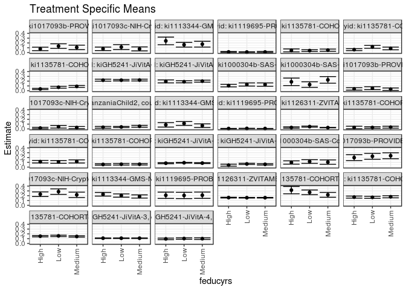

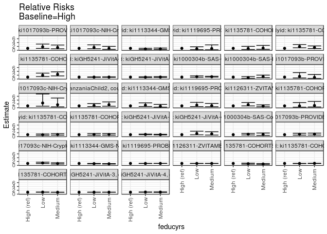

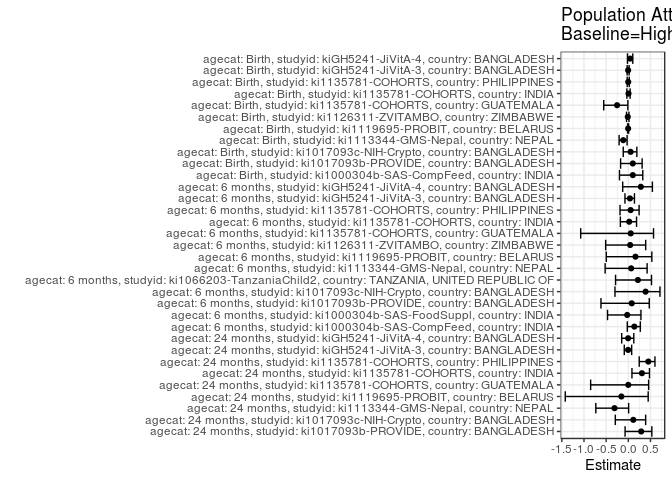

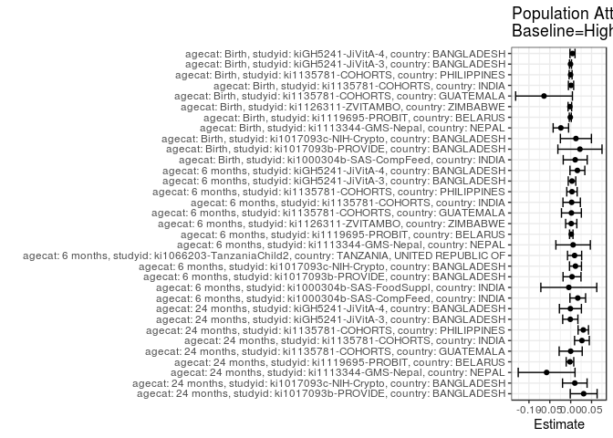

## Results Table

### Parameter: TSM

| agecat | studyid | country | intervention_level | baseline_level | estimate | ci_lower | ci_upper |
| --- | --- | --- | --- | --- | --- | --- | --- |
| Birth | ki1000304b-SAS-CompFeed | INDIA | High | NA | 0.0963579 | 0.0623878 | 0.1303280 |
| Birth | ki1000304b-SAS-CompFeed | INDIA | Low | NA | 0.1156361 | 0.0771350 | 0.1541373 |
| Birth | ki1000304b-SAS-CompFeed | INDIA | Medium | NA | 0.1041317 | 0.0588957 | 0.1493676 |
| Birth | ki1017093b-PROVIDE | BANGLADESH | High | NA | 0.1977582 | 0.1362155 | 0.2593008 |
| Birth | ki1017093b-PROVIDE | BANGLADESH | Low | NA | 0.2251870 | 0.1639764 | 0.2863975 |
| Birth | ki1017093b-PROVIDE | BANGLADESH | Medium | NA | 0.2365384 | 0.1745623 | 0.2985145 |
| Birth | ki1017093c-NIH-Crypto | BANGLADESH | High | NA | 0.2307765 | 0.1825924 | 0.2789606 |
| Birth | ki1017093c-NIH-Crypto | BANGLADESH | Low | NA | 0.2847880 | 0.2275860 | 0.3419900 |
| Birth | ki1017093c-NIH-Crypto | BANGLADESH | Medium | NA | 0.2179368 | 0.1621980 | 0.2736757 |
| Birth | ki1113344-GMS-Nepal | NEPAL | High | NA | 0.2297967 | 0.1920211 | 0.2675723 |
| Birth | ki1113344-GMS-Nepal | NEPAL | Low | NA | 0.2029262 | 0.1692900 | 0.2365625 |
| Birth | ki1113344-GMS-Nepal | NEPAL | Medium | NA | 0.1835636 | 0.1500269 | 0.2171004 |
| Birth | ki1119695-PROBIT | BELARUS | High | NA | 0.2087412 | 0.1433141 | 0.2741683 |
| Birth | ki1119695-PROBIT | BELARUS | Low | NA | 0.2050638 | 0.1399022 | 0.2702254 |
| Birth | ki1119695-PROBIT | BELARUS | Medium | NA | 0.2098909 | 0.1440496 | 0.2757322 |
| Birth | ki1126311-ZVITAMBO | ZIMBABWE | High | NA | 0.1597471 | 0.1520232 | 0.1674710 |
| Birth | ki1126311-ZVITAMBO | ZIMBABWE | Low | NA | 0.1573287 | 0.1501871 | 0.1644704 |
| Birth | ki1126311-ZVITAMBO | ZIMBABWE | Medium | NA | 0.1576177 | 0.1511933 | 0.1640421 |
| Birth | ki1135781-COHORTS | GUATEMALA | High | NA | 0.3159736 | 0.2396025 | 0.3923447 |
| Birth | ki1135781-COHORTS | GUATEMALA | Low | NA | 0.2699117 | 0.2210172 | 0.3188061 |
| Birth | ki1135781-COHORTS | GUATEMALA | Medium | NA | 0.2177062 | 0.1674470 | 0.2679654 |
| Birth | ki1135781-COHORTS | INDIA | High | NA | 0.1703617 | 0.1487781 | 0.1919453 |
| Birth | ki1135781-COHORTS | INDIA | Low | NA | 0.1654840 | 0.1444352 | 0.1865328 |
| Birth | ki1135781-COHORTS | INDIA | Medium | NA | 0.1773061 | 0.1554761 | 0.1991360 |
| Birth | ki1135781-COHORTS | PHILIPPINES | High | NA | 0.1508995 | 0.1369335 | 0.1648655 |
| Birth | ki1135781-COHORTS | PHILIPPINES | Low | NA | 0.1574984 | 0.1431603 | 0.1718364 |
| Birth | ki1135781-COHORTS | PHILIPPINES | Medium | NA | 0.1456813 | 0.1320695 | 0.1592931 |
| Birth | kiGH5241-JiVitA-3 | BANGLADESH | High | NA | 0.1094828 | 0.1037442 | 0.1152214 |
| Birth | kiGH5241-JiVitA-3 | BANGLADESH | Low | NA | 0.1090590 | 0.1035598 | 0.1145581 |
| Birth | kiGH5241-JiVitA-3 | BANGLADESH | Medium | NA | 0.1089266 | 0.1032393 | 0.1146138 |

[output cut: 69 more lines]

### Parameter: E(Y)

| agecat | studyid | country | intervention_level | baseline_level | estimate | ci_lower | ci_upper |
| --- | --- | --- | --- | --- | --- | --- | --- |
| Birth | ki1000304b-SAS-CompFeed | INDIA | NA | NA | 0.1071753 | 0.0763487 | 0.1380019 |
| Birth | ki1017093b-PROVIDE | BANGLADESH | NA | NA | 0.2199248 | 0.1846953 | 0.2551543 |
| Birth | ki1017093c-NIH-Crypto | BANGLADESH | NA | NA | 0.2432815 | 0.2116319 | 0.2749310 |
| Birth | ki1113344-GMS-Nepal | NEPAL | NA | NA | 0.2062500 | 0.1748784 | 0.2376216 |
| Birth | ki1119695-PROBIT | BELARUS | NA | NA | 0.2077971 | 0.1423827 | 0.2732114 |
| Birth | ki1126311-ZVITAMBO | ZIMBABWE | NA | NA | 0.1577985 | 0.1514260 | 0.1641709 |
| Birth | ki1135781-COHORTS | GUATEMALA | NA | NA | 0.2520891 | 0.2203065 | 0.2838718 |
| Birth | ki1135781-COHORTS | INDIA | NA | NA | 0.1711851 | 0.1506302 | 0.1917400 |
| Birth | ki1135781-COHORTS | PHILIPPINES | NA | NA | 0.1506598 | 0.1372339 | 0.1640858 |
| Birth | kiGH5241-JiVitA-3 | BANGLADESH | NA | NA | 0.1090574 | 0.1037994 | 0.1143154 |
| Birth | kiGH5241-JiVitA-4 | BANGLADESH | NA | NA | 0.0998709 | 0.0841992 | 0.1155426 |
| 6 months | ki1000304b-SAS-CompFeed | INDIA | NA | NA | 0.1239669 | 0.0988748 | 0.1490591 |
| 6 months | ki1000304b-SAS-FoodSuppl | INDIA | NA | NA | 0.1815789 | 0.1427684 | 0.2203895 |
| 6 months | ki1017093b-PROVIDE | BANGLADESH | NA | NA | 0.0414594 | 0.0255348 | 0.0573839 |
| 6 months | ki1017093c-NIH-Crypto | BANGLADESH | NA | NA | 0.0293706 | 0.0169860 | 0.0417552 |
| 6 months | ki1066203-TanzaniaChild2 | TANZANIA, UNITED REPUBLIC OF | NA | NA | 0.0431334 | 0.0342652 | 0.0520016 |
| 6 months | ki1113344-GMS-Nepal | NEPAL | NA | NA | 0.0905861 | 0.0668565 | 0.1143158 |
| 6 months | ki1119695-PROBIT | BELARUS | NA | NA | 0.0084166 | 0.0066777 | 0.0101555 |
| 6 months | ki1126311-ZVITAMBO | ZIMBABWE | NA | NA | 0.0307283 | 0.0270076 | 0.0344489 |
| 6 months | ki1135781-COHORTS | GUATEMALA | NA | NA | 0.0320442 | 0.0205636 | 0.0435248 |
| 6 months | ki1135781-COHORTS | INDIA | NA | NA | 0.1148014 | 0.0980067 | 0.1315962 |
| 6 months | ki1135781-COHORTS | PHILIPPINES | NA | NA | 0.0581577 | 0.0490934 | 0.0672220 |
| 6 months | kiGH5241-JiVitA-3 | BANGLADESH | NA | NA | 0.0845079 | 0.0795688 | 0.0894470 |
| 6 months | kiGH5241-JiVitA-4 | BANGLADESH | NA | NA | 0.0567164 | 0.0477001 | 0.0657328 |
| 24 months | ki1017093b-PROVIDE | BANGLADESH | NA | NA | 0.1070812 | 0.0818727 | 0.1322897 |
| 24 months | ki1017093c-NIH-Crypto | BANGLADESH | NA | NA | 0.0875486 | 0.0630907 | 0.1120065 |
| 24 months | ki1113344-GMS-Nepal | NEPAL | NA | NA | 0.1851852 | 0.1506144 | 0.2197560 |
| 24 months | ki1119695-PROBIT | BELARUS | NA | NA | 0.0111601 | 0.0050716 | 0.0172486 |
| 24 months | ki1135781-COHORTS | GUATEMALA | NA | NA | 0.0449102 | 0.0320802 | 0.0577401 |
| 24 months | ki1135781-COHORTS | INDIA | NA | NA | 0.0875912 | 0.0726161 | 0.1025664 |
| 24 months | ki1135781-COHORTS | PHILIPPINES | NA | NA | 0.0668392 | 0.0566723 | 0.0770060 |
| 24 months | kiGH5241-JiVitA-3 | BANGLADESH | NA | NA | 0.2187803 | 0.2086815 | 0.2288790 |
| 24 months | kiGH5241-JiVitA-4 | BANGLADESH | NA | NA | 0.1938288 | 0.1801571 | 0.2075004 |

### Parameter: RR

| agecat | studyid | country | intervention_level | baseline_level | estimate | ci_lower | ci_upper |
| --- | --- | --- | --- | --- | --- | --- | --- |
| Birth | ki1000304b-SAS-CompFeed | INDIA | High | High | 1.0000000 | 1.0000000 | 1.0000000 |
| Birth | ki1000304b-SAS-CompFeed | INDIA | Low | High | 1.2000693 | 0.8660390 | 1.6629347 |
| Birth | ki1000304b-SAS-CompFeed | INDIA | Medium | High | 1.0806761 | 0.6239201 | 1.8718117 |
| Birth | ki1017093b-PROVIDE | BANGLADESH | High | High | 1.0000000 | 1.0000000 | 1.0000000 |
| Birth | ki1017093b-PROVIDE | BANGLADESH | Low | High | 1.1386988 | 0.7539347 | 1.7198239 |
| Birth | ki1017093b-PROVIDE | BANGLADESH | Medium | High | 1.1960993 | 0.7962403 | 1.7967609 |
| Birth | ki1017093c-NIH-Crypto | BANGLADESH | High | High | 1.0000000 | 1.0000000 | 1.0000000 |
| Birth | ki1017093c-NIH-Crypto | BANGLADESH | Low | High | 1.2340423 | 0.9285546 | 1.6400334 |
| Birth | ki1017093c-NIH-Crypto | BANGLADESH | Medium | High | 0.9443631 | 0.6842099 | 1.3034327 |
| Birth | ki1113344-GMS-Nepal | NEPAL | High | High | 1.0000000 | 1.0000000 | 1.0000000 |
| Birth | ki1113344-GMS-Nepal | NEPAL | Low | High | 0.8830686 | 0.7826796 | 0.9963340 |
| Birth | ki1113344-GMS-Nepal | NEPAL | Medium | High | 0.7988089 | 0.6918202 | 0.9223432 |
| Birth | ki1119695-PROBIT | BELARUS | High | High | 1.0000000 | 1.0000000 | 1.0000000 |
| Birth | ki1119695-PROBIT | BELARUS | Low | High | 0.9823833 | 0.9600627 | 1.0052227 |
| Birth | ki1119695-PROBIT | BELARUS | Medium | High | 1.0055080 | 0.9925538 | 1.0186312 |
| Birth | ki1126311-ZVITAMBO | ZIMBABWE | High | High | 1.0000000 | 1.0000000 | 1.0000000 |
| Birth | ki1126311-ZVITAMBO | ZIMBABWE | Low | High | 0.9848614 | 0.9503552 | 1.0206205 |
| Birth | ki1126311-ZVITAMBO | ZIMBABWE | Medium | High | 0.9866707 | 0.9581148 | 1.0160777 |
| Birth | ki1135781-COHORTS | GUATEMALA | High | High | 1.0000000 | 1.0000000 | 1.0000000 |
| Birth | ki1135781-COHORTS | GUATEMALA | Low | High | 0.8542222 | 0.6345342 | 1.1499704 |
| Birth | ki1135781-COHORTS | GUATEMALA | Medium | High | 0.6890011 | 0.4950521 | 0.9589344 |
| Birth | ki1135781-COHORTS | INDIA | High | High | 1.0000000 | 1.0000000 | 1.0000000 |
| Birth | ki1135781-COHORTS | INDIA | Low | High | 0.9713684 | 0.9075991 | 1.0396184 |
| Birth | ki1135781-COHORTS | INDIA | Medium | High | 1.0407623 | 0.9746225 | 1.1113906 |
| Birth | ki1135781-COHORTS | PHILIPPINES | High | High | 1.0000000 | 1.0000000 | 1.0000000 |
| Birth | ki1135781-COHORTS | PHILIPPINES | Low | High | 1.0437301 | 0.9973915 | 1.0922217 |
| Birth | ki1135781-COHORTS | PHILIPPINES | Medium | High | 0.9654193 | 0.9261611 | 1.0063417 |
| Birth | kiGH5241-JiVitA-3 | BANGLADESH | High | High | 1.0000000 | 1.0000000 | 1.0000000 |
| Birth | kiGH5241-JiVitA-3 | BANGLADESH | Low | High | 0.9961284 | 0.9648603 | 1.0284098 |
| Birth | kiGH5241-JiVitA-3 | BANGLADESH | Medium | High | 0.9949192 | 0.9623871 | 1.0285510 |

[output cut: 69 more lines]

### Parameter: PAR

| agecat | studyid | country | intervention_level | baseline_level | estimate | ci_lower | ci_upper |
| --- | --- | --- | --- | --- | --- | --- | --- |
| Birth | ki1000304b-SAS-CompFeed | INDIA | High | NA | 0.0108174 | -0.0179029 | 0.0395378 |
| Birth | ki1017093b-PROVIDE | BANGLADESH | High | NA | 0.0221667 | -0.0306887 | 0.0750220 |
| Birth | ki1017093c-NIH-Crypto | BANGLADESH | High | NA | 0.0125049 | -0.0246660 | 0.0496759 |
| Birth | ki1113344-GMS-Nepal | NEPAL | High | NA | -0.0235467 | -0.0420443 | -0.0050491 |
| Birth | ki1119695-PROBIT | BELARUS | High | NA | -0.0009441 | -0.0033573 | 0.0014691 |
| Birth | ki1126311-ZVITAMBO | ZIMBABWE | High | NA | -0.0019486 | -0.0062523 | 0.0023551 |
| Birth | ki1135781-COHORTS | GUATEMALA | High | NA | -0.0638845 | -0.1318923 | 0.0041233 |
| Birth | ki1135781-COHORTS | INDIA | High | NA | 0.0008234 | -0.0054399 | 0.0070867 |
| Birth | ki1135781-COHORTS | PHILIPPINES | High | NA | -0.0002397 | -0.0037697 | 0.0032903 |
| Birth | kiGH5241-JiVitA-3 | BANGLADESH | High | NA | -0.0004254 | -0.0028657 | 0.0020148 |
| Birth | kiGH5241-JiVitA-4 | BANGLADESH | High | NA | 0.0042360 | -0.0018450 | 0.0103169 |
| 6 months | ki1000304b-SAS-CompFeed | INDIA | High | NA | 0.0169112 | -0.0018697 | 0.0356921 |
| 6 months | ki1000304b-SAS-FoodSuppl | INDIA | High | NA | -0.0045182 | -0.0715070 | 0.0624705 |
| 6 months | ki1017093b-PROVIDE | BANGLADESH | High | NA | 0.0031819 | -0.0183012 | 0.0246649 |
| 6 months | ki1017093c-NIH-Crypto | BANGLADESH | High | NA | 0.0114495 | -0.0029263 | 0.0258253 |
| 6 months | ki1066203-TanzaniaChild2 | TANZANIA, UNITED REPUBLIC OF | High | NA | 0.0093284 | -0.0075706 | 0.0262273 |
| 6 months | ki1113344-GMS-Nepal | NEPAL | High | NA | 0.0057673 | -0.0355072 | 0.0470419 |
| 6 months | ki1119695-PROBIT | BELARUS | High | NA | 0.0013592 | -0.0027745 | 0.0054928 |
| 6 months | ki1126311-ZVITAMBO | ZIMBABWE | High | NA | 0.0012749 | -0.0121265 | 0.0146763 |
| 6 months | ki1135781-COHORTS | GUATEMALA | High | NA | 0.0017412 | -0.0220695 | 0.0255519 |
| 6 months | ki1135781-COHORTS | INDIA | High | NA | 0.0023038 | -0.0185425 | 0.0231501 |
| 6 months | ki1135781-COHORTS | PHILIPPINES | High | NA | 0.0030396 | -0.0093739 | 0.0154532 |
| 6 months | kiGH5241-JiVitA-3 | BANGLADESH | High | NA | 0.0031414 | -0.0058766 | 0.0121595 |
| 6 months | kiGH5241-JiVitA-4 | BANGLADESH | High | NA | 0.0160163 | -0.0017868 | 0.0338195 |
| 24 months | ki1017093b-PROVIDE | BANGLADESH | High | NA | 0.0310885 | -0.0011226 | 0.0632997 |
| 24 months | ki1017093c-NIH-Crypto | BANGLADESH | High | NA | 0.0098522 | -0.0195429 | 0.0392474 |
| 24 months | ki1113344-GMS-Nepal | NEPAL | High | NA | -0.0577164 | -0.1257421 | 0.0103094 |
| 24 months | ki1119695-PROBIT | BELARUS | High | NA | -0.0017431 | -0.0108060 | 0.0073198 |
| 24 months | ki1135781-COHORTS | GUATEMALA | High | NA | -0.0000336 | -0.0276458 | 0.0275785 |
| 24 months | ki1135781-COHORTS | INDIA | High | NA | 0.0269184 | 0.0092647 | 0.0445722 |
| 24 months | ki1135781-COHORTS | PHILIPPINES | High | NA | 0.0301679 | 0.0176863 | 0.0426495 |
| 24 months | kiGH5241-JiVitA-3 | BANGLADESH | High | NA | -0.0009421 | -0.0191566 | 0.0172723 |
| 24 months | kiGH5241-JiVitA-4 | BANGLADESH | High | NA | -0.0007038 | -0.0270904 | 0.0256828 |

### Parameter: PAF

| agecat | studyid | country | intervention_level | baseline_level | estimate | ci_lower | ci_upper |
| --- | --- | --- | --- | --- | --- | --- | --- |
| Birth | ki1000304b-SAS-CompFeed | INDIA | High | NA | 0.1009320 | -0.1995245 | 0.3261303 |
| Birth | ki1017093b-PROVIDE | BANGLADESH | High | NA | 0.1007919 | -0.1740298 | 0.3112823 |
| Birth | ki1017093c-NIH-Crypto | BANGLADESH | High | NA | 0.0514011 | -0.1143477 | 0.1924964 |
| Birth | ki1113344-GMS-Nepal | NEPAL | High | NA | -0.1141657 | -0.2077491 | -0.0278338 |
| Birth | ki1119695-PROBIT | BELARUS | High | NA | -0.0045434 | -0.0163317 | 0.0071082 |
| Birth | ki1126311-ZVITAMBO | ZIMBABWE | High | NA | -0.0123486 | -0.0399923 | 0.0145602 |
| Birth | ki1135781-COHORTS | GUATEMALA | High | NA | -0.2534202 | -0.5549665 | -0.0103511 |
| Birth | ki1135781-COHORTS | INDIA | High | NA | 0.0048101 | -0.0324731 | 0.0407469 |
| Birth | ki1135781-COHORTS | PHILIPPINES | High | NA | -0.0015909 | -0.0252941 | 0.0215644 |
| Birth | kiGH5241-JiVitA-3 | BANGLADESH | High | NA | -0.0039009 | -0.0265336 | 0.0182329 |
| Birth | kiGH5241-JiVitA-4 | BANGLADESH | High | NA | 0.0424144 | -0.0196006 | 0.1006575 |
| 6 months | ki1000304b-SAS-CompFeed | INDIA | High | NA | 0.1364172 | -0.0229592 | 0.2709628 |
| 6 months | ki1000304b-SAS-FoodSuppl | INDIA | High | NA | -0.0248830 | -0.4687866 | 0.2848620 |
| 6 months | ki1017093b-PROVIDE | BANGLADESH | High | NA | 0.0767464 | -0.6169746 | 0.4728444 |
| 6 months | ki1017093c-NIH-Crypto | BANGLADESH | High | NA | 0.3898276 | -0.3012672 | 0.7138863 |
| 6 months | ki1066203-TanzaniaChild2 | TANZANIA, UNITED REPUBLIC OF | High | NA | 0.2162678 | -0.2878276 | 0.5230448 |
| 6 months | ki1113344-GMS-Nepal | NEPAL | High | NA | 0.0636669 | -0.5228619 | 0.4242947 |
| 6 months | ki1119695-PROBIT | BELARUS | High | NA | 0.1614860 | -0.4976504 | 0.5305274 |
| 6 months | ki1126311-ZVITAMBO | ZIMBABWE | High | NA | 0.0414894 | -0.5107455 | 0.3918615 |
| 6 months | ki1135781-COHORTS | GUATEMALA | High | NA | 0.0543365 | -1.0743176 | 0.5688801 |
| 6 months | ki1135781-COHORTS | INDIA | High | NA | 0.0200676 | -0.1793419 | 0.1857599 |
| 6 months | ki1135781-COHORTS | PHILIPPINES | High | NA | 0.0522656 | -0.1869515 | 0.2432710 |
| 6 months | kiGH5241-JiVitA-3 | BANGLADESH | High | NA | 0.0371730 | -0.0757942 | 0.1382777 |
| 6 months | kiGH5241-JiVitA-4 | BANGLADESH | High | NA | 0.2823934 | -0.1268115 | 0.5429944 |
| 24 months | ki1017093b-PROVIDE | BANGLADESH | High | NA | 0.2903269 | -0.0729619 | 0.5306116 |
| 24 months | ki1017093c-NIH-Crypto | BANGLADESH | High | NA | 0.1125346 | -0.2934920 | 0.3911096 |
| 24 months | ki1113344-GMS-Nepal | NEPAL | High | NA | -0.3116684 | -0.7331267 | 0.0073005 |
| 24 months | ki1119695-PROBIT | BELARUS | High | NA | -0.1561890 | -1.4222360 | 0.4481243 |
| 24 months | ki1135781-COHORTS | GUATEMALA | High | NA | -0.0007491 | -0.8498780 | 0.4586137 |
| 24 months | ki1135781-COHORTS | INDIA | High | NA | 0.3073187 | 0.0819564 | 0.4773588 |
| 24 months | ki1135781-COHORTS | PHILIPPINES | High | NA | 0.4513508 | 0.2461537 | 0.6006931 |
| 24 months | kiGH5241-JiVitA-3 | BANGLADESH | High | NA | -0.0043064 | -0.0911176 | 0.0755980 |
| 24 months | kiGH5241-JiVitA-4 | BANGLADESH | High | NA | -0.0036310 | -0.1494044 | 0.1236546 |